# **Saumya Kothari - Computer Vision Project 1 (Part 1, 2)**

## **Part 1**

#### **DOMAIN:**

Botanical research

#### **CONTEXT:**

University X is currently undergoing some research involving understanding the characteristics of plant and plant seedlings at various stages of growth. They already have have invested on curating sample images. They require an automation which can create a classifier capable of determining a plant's species from a photo.

#### **DATA DESCRIPTION:**

The dataset comprises of images from 12 plant species. Source: https://www.kaggle.com/c/ plant-seedlings-classification/data

#### **PROJECT OBJECTIVE:**

University’s management require an automation which can create a classifier capable of determining a plant's species from a photo

**Steps and tasks: [ Total Score: 20 points]**

1. Import the data. Analyse the dimensions of the data. Visualise the data.
2. Train tune and test AIML image classifier model using: • Use supervised learning algorithms for training • Use neural networks for training • Use CNN for training
3. Compare the results from the above step along with your detailed observations.
4. Pickle the best performing model.
5. Import the the image in the “ Prediction” folder to predict the class. Display the image. Use the best trained image classifier model to predict the class.

. . .

## **Part 2**

**TASK:**

Explain in depth why CNN out performs neural networks which in turn out perform supervised learning models when it comes to image classification. Use the markdown option in Jupiter for your answer.

# Solution

## Part 1

```python
import matplotlib.pyplot as plt
import numpy as np
import os
import PIL
import tensorflow as tf
import pathlib

from tensorflow import keras
from tensorflow.keras import layers
from tensorflow.keras.models import Sequential

import cv2
import keras
from keras.layers import Dense,Conv2D,Dropout,BatchNormalization,Activation,Flatten,MaxPool2D,Input,LeakyReLU
from keras.models import Sequential
from keras.activations import relu
from keras.optimizers import Adam,RMSprop,SGD
from keras.preprocessing.image import ImageDataGenerator

#from keras.utils import to_categorical
import pandas as pd
import numpy as np
from keras.applications.vgg16 import VGG16
from sklearn import svm
from keras.preprocessing import image
import xgboost
from sklearn.linear_model import LogisticRegression
from sklearn.metrics import accuracy_score
import os
from sklearn.model_selection import train_test_split
import sklearn.preprocessing as pr
from sklearn.metrics import accuracy_score
from sklearn.svm import SVC
from sklearn.metrics import roc_curve, auc
from mpl_toolkits.axes_grid1 import ImageGrid
```

```python
data_dir_train_path = '/content/drive/MyDrive/ComputerVision/train'
data_dir_train = pathlib.Path(data_dir_train_path)

folder_train = list(data_dir_train.glob('*'))
images_train = list(data_dir_train.glob('*/*.png')) #list of all images (full path)
```

```python
# Color Class to Bold and Color words while printing
class color:
    PURPLE = '\033[95m'
    CYAN = '\033[96m'
    DARKCYAN = '\033[36m'
    BLUE = '\033[94m'
    GREEN = '\033[92m'
    YELLOW = '\033[93m'
    RED = '\033[91m'
    BOLD = '\033[1m'
    UNDERLINE = '\033[4m'
    END = '\033[0m'
```

```python
base_path = os.getcwd()
train_path=base_path+'/train'
test_path=base_path+'/test'
```

### Importing Data

```python
categories = ['Black-grass', 'Charlock', 'Cleavers', 'Common Chickweed', 'Common wheat', 'Fat Hen','Loose Silky-bent',
           'Maize', 'Scentless Mayweed', 'Shepherds Purse','Small-flowered Cranesbill', 'Sugar beet']

for category in categories:
    print(category + " has " + color.GREEN + color.BOLD + str(len(os.listdir(os.path.join(train_path, category)))) + color.END + " images")
```

```
Black-grass has 263 images
Charlock has 390 images
Cleavers has 287 images
Common Chickweed has 611 images
Common wheat has 221 images
Fat Hen has 475 images
Loose Silky-bent has 654 images
Maize has 221 images
Scentless Mayweed has 516 images
Shepherds Purse has 231 images
Small-flowered Cranesbill has 496 images
Sugar beet has 385 images
```

```python
train = []
for category_id, category in enumerate(categories):
    for file in os.listdir(os.path.join(train_path, category)):
        train.append(['train/{}/{}'.format(category, file), category_id, category])
train = pd.DataFrame(train, columns=['file', 'category_id', 'category'])
train.head(2)
```

|  | file | category_id | category |
| --- | --- | --- | --- |
| 0 | train/Black-grass/0050f38b3.png | 0 | Black-grass |
| 1 | train/Black-grass/0183fdf68.png | 0 | Black-grass |

#### Exploring Data

```python
fig = plt.figure(figsize=(10, 10))
for i in range(9):
    plt.subplot(2, 3, i + 1)
    plt.title(str(images_train[i]).split('/')[-1], fontsize=10) #get the file name and disply as title
    plt.imshow(PIL.Image.open(images_train[i]))
    ax = plt.axis("off")
```

[figure not shown]

```python
batch_size = 32
img_height = 256
img_width = 256
```

```python
import numpy as np
import pandas as pd
import cv2
import os
from glob import glob
import matplotlib.pyplot as plt
import seaborn as sns
from PIL import ImageFile
ImageFile.LOAD_TRUNCATED_IMAGES = True
%matplotlib inline

#----------------------------------------------------------------

from keras.utils import np_utils
from keras.preprocessing import image
from keras.preprocessing.image import ImageDataGenerator, array_to_img, img_to_array, load_img
```

```python
images = []
classes=[]
for class_folder_name in os.listdir(data_dir_train_path):
    class_folder_path = os.path.join(data_dir_train_path, class_folder_name)
    class_label = class_folder_name

    for image_path in glob(os.path.join(class_folder_path, "*.png")):
        image_bgr = cv2.imread(image_path, cv2.IMREAD_COLOR)
        images.append(image_bgr)
        classes.append(class_label)
```

```python
images = np.array(images)
classes = np.array(classes)
values =[]
labels=[]
for label in set(classes):
    values.append(len(images[classes == label]))
    labels.append(label)

fig, ax = plt.subplots(figsize=(22,7))
ax.bar(labels, values)
ax.set_xlabel("Species")
ax.set_ylabel("Number of images")
fig.suptitle('Class Distribution of the dataset')
```

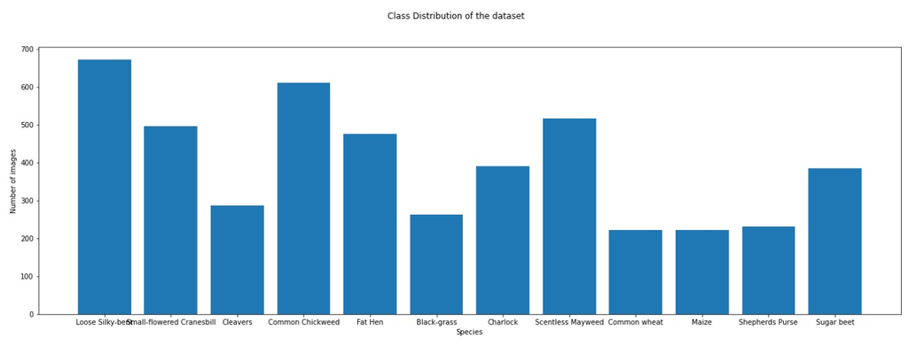

```python
fig, axs = plt.subplots(1, 4, figsize=(15,15))
axs[0].imshow(images[0])
axs[1].imshow(images[10])
axs[2].imshow(images[42])
axs[3].imshow(images[65])
```

[figure not shown]

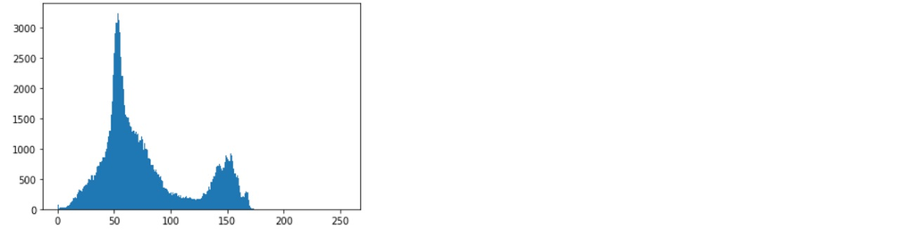

```python
plt.hist(images[0].ravel(),256,[0,255])
plt.show()
```

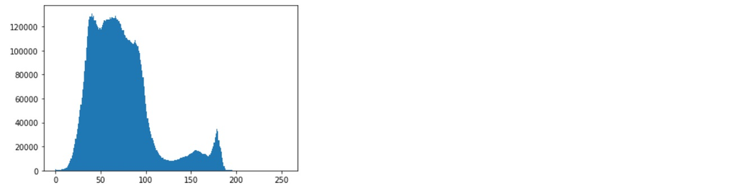

```python
plt.hist(images[10].ravel(),256,[0,255])
plt.show()
```

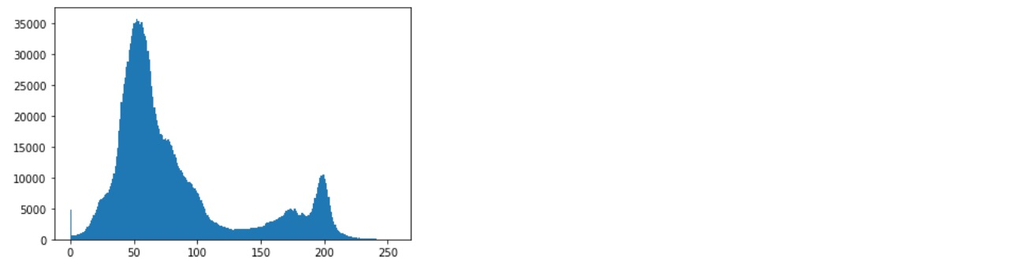

```python
plt.hist(images[42].ravel(),256,[0,255])
plt.show()
```

**From the histograms of our sample images, we can infer that:**

- The intensities of the images are highly skewed towards left. That means, the images are darker.
- Most the values of intensities in our images lie between the range 0-150.
- Performing histogram equalization might improve the model score, even though it is not guaranteed.

```python
sample_per_category = 200
seed = 43
```

```python
train = pd.concat([train[train['category'] == c][:sample_per_category] for c in categories])
train = train.sample(frac=1)
train.index = np.arange(len(train))
train.head(2)
train.shape
```

```
(2400, 3)
```

```python
test = []
for file in os.listdir(test_path):
    test.append(['test/{}'.format(file), file])
test = pd.DataFrame(test, columns=['filepath', 'file'])
test.head(2)
```

|  | filepath | file |
| --- | --- | --- |
| 0 | test/0021e90e4.png | 0021e90e4.png |
| 1 | test/003d61042.png | 003d61042.png |

```python
def read_img(filepath, size):
    img = image.load_img(os.path.join(base_path, filepath), target_size=size)
    img = image.img_to_array(img)
    return img
```

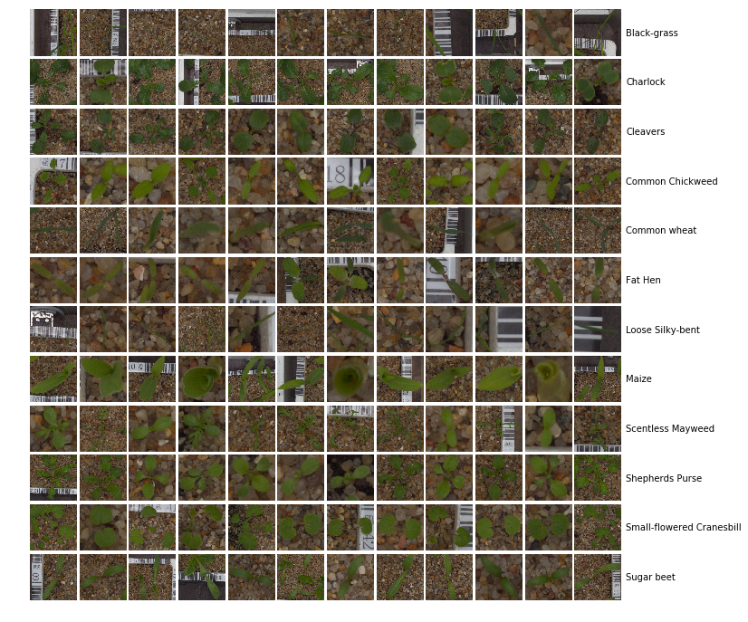

```python
num_catogeries = len(categories)
fig = plt.figure(1, figsize=(num_catogeries, num_catogeries))
grid = ImageGrid(fig, 111, nrows_ncols=(num_catogeries, num_catogeries), axes_pad=0.05)
i = 0
for category_id, category in enumerate(categories):
    for filepath in train[train['category'] == category]['file'].values[:num_catogeries]:
        ax = grid[i]
        img = read_img(filepath, (224, 224))
        ax.imshow(img / 255.)
        ax.axis('off')
        if i % num_catogeries == num_catogeries - 1:
            ax.text(250, 112, filepath.split('/')[1], verticalalignment='center')
        i += 1
plt.show();
```

```python
X = []
y = []
dim = []

for subfolder in os.listdir(train_path):
    for file in os.listdir(train_path+'\\' +subfolder):
        path = train_path+'\\' +subfolder+ "\\" + file
        im = cv2.imread(path)
        dim.append(list(im.shape))
        X.append(im)
        y.append(subfolder)
print(dim)
```

[output not shown]

## Train tune and test AIML image classifier model using:

### 1. Supervised Learning

```python
X_train = []
y_train = []

base_path = os.getcwd()
train_path=base_path+'\\train'
test_path=base_path+'\\test'

for subfolder in os.listdir(train_path):
    for file in os.listdir(train_path+'\\' +subfolder):
        path = train_path+'\\' +subfolder+ "\\" + file
        im = cv2.imread(path)
        ims = cv2.resize(im,(64,64))
        ims = ims/127.0
        X_train.append(ims)
        y_train.append(subfolder)
```

```python
from keras.utils import np_utils
```

```python
le = pr.LabelEncoder()
y_train_le = le.fit_transform(y_train)

x_svm,x_test_svm,y_svm,y_test_svm =  train_test_split(X_train,y_train_le ,test_size=0.2,random_state=10)
x_array_svm = np.array(x_svm)
x_test_arr_svm = np.array(x_test_svm)

y_train_cat = to_categorical(y_train_le)

flat_arr_size = len(x_array_svm[0])*len(x_array_svm[0][0])*len(x_array_svm[0][0][0])
x_arr_flat_svm = x_array_svm.reshape(len(x_array_svm),flat_arr_size)
x_test_arr_flat_svm = x_test_arr_svm.reshape(len(x_test_arr_svm),flat_arr_size)
```

```python
# define support vector classifier
svm = SVC(kernel='linear', probability=True, random_state=10)

# fit model
svm.fit(x_arr_flat_svm, y_svm)
```

```
SVC(C=1.0, break_ties=False, cache_size=200, class_weight=None, coef0=0.0,
    decision_function_shape='ovr', degree=3, gamma='scale', kernel='linear',
    max_iter=-1, probability=True, random_state=10, shrinking=True, tol=0.001,
    verbose=False)
```

```python
# generate predictions
y_pred = svm.predict(x_test_arr_flat_svm)

# calculate accuracy
accuracy = accuracy_score(y_test_svm, y_pred)
print('Model accuracy is: ', accuracy)
```

```
Model accuracy is:  0.5178947368421053
```

### 2. Neural Networks

```python
X_train_ann =[];
y_train_ann =[]

for subfolder in os.listdir(train_path):
    for file in os.listdir(train_path+'/' +subfolder):
        path = train_path+'/' +subfolder+ "/" + file
        im = cv2.imread(path)
        ims = cv2.resize(im,(128,128))
        ims = ims/255.0
        X_train_ann.append(ims)
        y_train_ann.append(subfolder)
```

```python
le_ann = pr.LabelEncoder()
y_train_le_ann = le_ann.fit_transform(y_train_ann)


x_ann,x_test_ann,y_ann,y_test_ann =  train_test_split(X_train_ann,y_train_le_ann ,test_size=0.2,random_state=10)

x_array_ann = np.array(x_ann)
x_test_arr_ann = np.array(x_test_ann)
y_train_ann_cat = to_categorical(y_ann)
y_test_ann_cat = to_categorical(y_test_ann)
```

```python
image_size = 256
batch_size = 32

idg = tf.keras.preprocessing.image.ImageDataGenerator(
    rescale=1./255,
    horizontal_flip=True,
    vertical_flip=True,
    validation_split=0.2)

train_gen = idg.flow_from_directory(train_path,
                                    target_size=(image_size, image_size),
                                    subset='training',
                                    class_mode='categorical',
                                    batch_size=batch_size,
                                    shuffle=True,
                                    seed=1)

val_gen = idg.flow_from_directory(train_path,
                                  target_size=(image_size, image_size),
                                  subset='validation',
                                  class_mode='categorical',
                                  batch_size=batch_size,
                                  shuffle=True,
                                  seed=1)
```

```
Found 3803 images belonging to 12 classes.
Found 947 images belonging to 12 classes.
```

```python
def nn_model():
    model_nn = Sequential()
    inputs = Input(shape=(128,128,3))
    model_nn.add(tf.keras.layers.Flatten())
    model_nn.add(Dense(512,activation = "relu"))
    model_nn.add(Dropout(0.2))

    # Normalization layer
    model_nn.add(tf.keras.layers.BatchNormalization())
    model_nn.add(Dense(256,activation = "relu"))
    model_nn.add(Dropout(0.2))

    # Normalization layer
    model_nn.add(tf.keras.layers.BatchNormalization())
    model_nn.add(Dense(128,activation = "relu"))
    model_nn.add(Dropout(0.2))

    # Normalization layer
    model_nn.add(tf.keras.layers.BatchNormalization())
    model_nn.add(Dense(32,activation = "relu"))
    model_nn.add(Dropout(0.2))
    model_nn.add(Dense(12,activation='softmax'))
    model_nn.compile(optimizer='adam', loss='categorical_crossentropy', metrics=['accuracy'])
    return model_nn

checkpoint_ann = tf.keras.callbacks.ModelCheckpoint('plant_ANN_classifier.h5',
                                                    save_best_only=True,
                                                    monitor='val_accuracy',
                                                    mode='max',
                                                    verbose = 1)
from tensorflow.keras import callbacks
earlystopping = callbacks.EarlyStopping(monitor ="val_loss",
                                        mode ="min", patience = 5,
                                        restore_best_weights = True)

# Build the model
model = nn_model()

history = model.fit_generator(train_gen,
          epochs=50, # Increase number of epochs if you have sufficient hardware
          steps_per_epoch= 3803//batch_size,  # Number of train images // batch_size
          validation_data=val_gen,
          validation_steps = 947//batch_size, # Number of val images // batch_size
          callbacks = [earlystopping],
          verbose = 1)

model.summary()
```

```
Model: "sequential"
_________________________________________________________________
Layer (type)                 Output Shape              Param #
=================================================================
flatten (Flatten)            (None, None)              0
_________________________________________________________________
dense (Dense)                (None, 512)               100663808
_________________________________________________________________
dropout (Dropout)            (None, 512)               0
_________________________________________________________________
batch_normalization (BatchNo (None, 512)               2048
_________________________________________________________________
dense_1 (Dense)              (None, 256)               131328
_________________________________________________________________
dropout_1 (Dropout)          (None, 256)               0
_________________________________________________________________
batch_normalization_1 (Batch (None, 256)               1024
_________________________________________________________________
dense_2 (Dense)              (None, 128)               32896
_________________________________________________________________
dropout_2 (Dropout)          (None, 128)               0
_________________________________________________________________
batch_normalization_2 (Batch (None, 128)               512
_________________________________________________________________
dense_3 (Dense)              (None, 32)                4128
_________________________________________________________________
dropout_3 (Dropout)          (None, 32)                0
_________________________________________________________________
dense_4 (Dense)              (None, 12)                396
=================================================================
Total params: 100,836,140
Trainable params: 100,834,348
Non-trainable params: 1,792
_________________________________________________________________
```

### 3. CNN

```python
def cnn_model():
    model = tf.keras.models.Sequential()
    model.add(tf.keras.layers.InputLayer(input_shape=(image_size,image_size,3,)))
    model.add(tf.keras.layers.Conv2D(64, kernel_size=(3,3), activation='relu'))
    model.add(tf.keras.layers.MaxPool2D(pool_size = (2,2)))
    model.add(tf.keras.layers.BatchNormalization())
    model.add(tf.keras.layers.Conv2D(64, kernel_size=(3,3), strides = (1,1), activation='relu'))
    model.add(tf.keras.layers.MaxPool2D(pool_size = (2,2)))
    model.add(tf.keras.layers.BatchNormalization())
    model.add(tf.keras.layers.Conv2D(128, kernel_size=(3,3), strides = (1,1), activation='relu'))
    model.add(tf.keras.layers.MaxPool2D(pool_size = (2,2)))
    model.add(tf.keras.layers.BatchNormalization())
    model.add(tf.keras.layers.Conv2D(128, kernel_size=(3,3), strides = (1,1), activation='relu'))
    model.add(tf.keras.layers.MaxPool2D(pool_size = (2,2)))
    model.add(tf.keras.layers.GlobalMaxPool2D())
    model.add(tf.keras.layers.Flatten())
    model.add(tf.keras.layers.Dense(128, activation='relu'))
    model.add(tf.keras.layers.Dropout(0.2))
    model.add(tf.keras.layers.Dense(64, activation='relu'))
    model.add(tf.keras.layers.BatchNormalization())
    model.add(tf.keras.layers.Dense(12, activation='softmax'))
    model.compile(optimizer='adam', loss='categorical_crossentropy', metrics=['accuracy'])
    return model

earlystopping = callbacks.EarlyStopping(monitor ="val_loss",
                                        mode ="min", patience = 5,
                                        restore_best_weights = True)

model = cnn_model()

history = model.fit(train_gen,
                    epochs=15,
                    steps_per_epoch= 3803//batch_size,
                    validation_data=val_gen,
                    validation_steps = 947//batch_size,
                    callbacks = [earlystopping],
                    verbose = 1)

model.summary()
```

```
Model: "sequential_9"
_________________________________________________________________
Layer (type)                 Output Shape              Param #
=================================================================
conv2d_32 (Conv2D)           (None, 254, 254, 64)      1792
_________________________________________________________________
max_pooling2d_32 (MaxPooling (None, 127, 127, 64)      0
_________________________________________________________________
batch_normalization_35 (Batc (None, 127, 127, 64)      256
_________________________________________________________________
conv2d_33 (Conv2D)           (None, 125, 125, 64)      36928
_________________________________________________________________
max_pooling2d_33 (MaxPooling (None, 62, 62, 64)        0
_________________________________________________________________
batch_normalization_36 (Batc (None, 62, 62, 64)        256
_________________________________________________________________
conv2d_34 (Conv2D)           (None, 60, 60, 128)       73856
_________________________________________________________________
max_pooling2d_34 (MaxPooling (None, 30, 30, 128)       0
_________________________________________________________________
batch_normalization_37 (Batc (None, 30, 30, 128)       512
_________________________________________________________________
conv2d_35 (Conv2D)           (None, 28, 28, 128)       147584
_________________________________________________________________
max_pooling2d_35 (MaxPooling (None, 14, 14, 128)       0
_________________________________________________________________
global_max_pooling2d_8 (Glob (None, 128)               0
_________________________________________________________________
flatten_9 (Flatten)          (None, 128)               0
_________________________________________________________________
dense_29 (Dense)             (None, 128)               16512
_________________________________________________________________
dropout_12 (Dropout)         (None, 128)               0
_________________________________________________________________
dense_30 (Dense)             (None, 64)                8256
_________________________________________________________________
batch_normalization_38 (Batc (None, 64)                256
_________________________________________________________________
dense_31 (Dense)             (None, 12)                780
=================================================================
Total params: 286,988
Trainable params: 286,348
Non-trainable params: 640
_________________________________________________________________
```

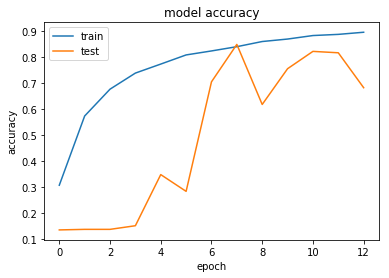

```python
#summarize history for accuracy

plt.plot(history.history['accuracy'])
plt.plot(history.history['val_accuracy'])
plt.title('model accuracy')
plt.ylabel('accuracy')
plt.xlabel('epoch')
plt.legend(['train','test'],loc='upper left')
plt.show()
```

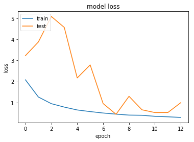

```python
# summarize history for loss

plt.plot(history.history['loss'])
plt.plot(history.history['val_loss'])
plt.title('model loss')
plt.ylabel('loss')
plt.xlabel('epoch')
plt.legend(['train','test'],loc='upper left')
plt.show()
```

##### Observations other than accuracy levels:

1. Though it is faster to train an SVC, the CNN gives much better results.
2. We could have made the SVC, but with the CNN we do not have to explicitly do that.
3. It also took less time to run CNN as compared to ANN

### Pickle the best performing model.

```python
model.save("CNN_Model.h5") #using h5 extension
print("The model has been successfully saved. Thank you!")
```

```
The model has been successfully saved. Thank you!
```

### Import the the image in the “Prediction” folder to predict the class. Display the image. Use the best trained image classifier model to predict the class.

```python
from tensorflow.keras.models import load_model

# load the model
model = load_model('CNN_Model.h5')
```

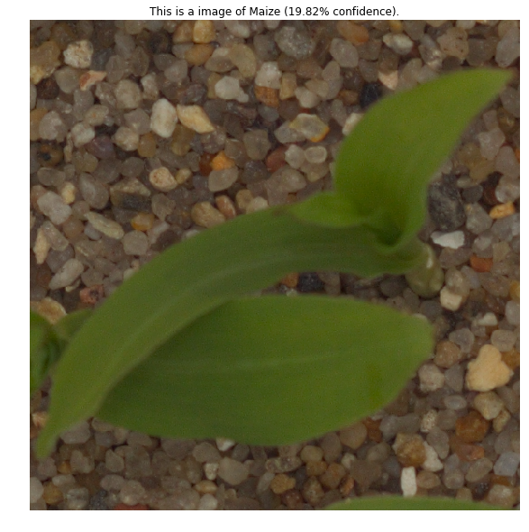

```python
import PIL

img = keras.preprocessing.image.load_img(base_path+'/predict/Predict.png', target_size=(256, 256))
img_array = keras.preprocessing.image.img_to_array(img)
img_array = tf.expand_dims(img_array, 0)

predictions = model.predict(img_array)
score = tf.nn.softmax(predictions[0])

plt.figure(figsize=(10, 10))
plt.title("This is a image of {} ({:.2f}% confidence).".format(categories[np.argmax(score)], 100 * np.max(score)), fontsize=12)
plt.imshow(PIL.Image.open(base_path+'/predict/Predict.png'))
ax = plt.axis("off")
```

# Part 2

### Explain in depth why CNN out performs neural networks which in turn out perform supervised learning models when it comes to image classification.

#### CNN is better than Neural Networks:

Convolution Neural Networks (CNN) are one of the most popular models used today. This neural network computational model uses a variation of multilayer perceptrons and contains one or more convolutional layers that can be either entirely connected or pooled. These convolutional layers create feature maps that record a region of image which is ultimately broken into rectangles and sent out for nonlinear processing.

Advantages of CNN:

- Very High accuracy in image recognition problems.
- Automatically detects the important features without any human supervision.
- Weight sharing.

Neural Networks (or Aritificial Neural Networks(ANN)) have their neurons fully connected in the previous layer. Because of these large number of connections, the number of parameters to be learned increases and the network becomes more complex leading to overfitting. When it comes to image classification, this is the primary challenge because all feautures and parts of the image are not considered important and in fact waste a lot of memory space.

Convolution Neural Networks (CNN) were discovered to fix this problem. Here, the input image data is put through a set of convolution operations such as filtration and max pooling. The resultant data, of lesser dimension compared to the original image data, will be subjected to Fully connected layers to predict output.

The reason why Convolutional Neural Networks (CNNs) are better than classic Neural Networks on images and videos:

1. There are the pooling layers in Convolution Neural Network algorithms which downscale the image. One reason is to reduce the computational load on the system. By reducing the quality of the image, you can increase the “depth” of the layer, meaning it will be looking for more features in the reduced image. The pooling layer summarises the features present in a region of the feature map generated by a convolution layer. So, further operations are performed on summarised features instead of precisely positioned features generated by the convolution layer. This makes the model more robust to variations in the position of the features in the input image. This is possible because we retain throughout the network, features that are organized spatially like an image, and thus downscaling them makes sense as reducing the size of the image. On classic neural network inputs you cannot downscale a vector.
2. For a completely new task / problem CNNs are very good feature extractors. This means that you can extract useful attributes from an already trained CNN with its trained weights by feeding your data on each level and tune the CNN a bit for the specific task. Eg : Add a classifier after the last layer with labels specific to the task. This is also called pre-training and CNNs are very efficient in such tasks compared to NNs. Another advantage of this pre-training is we avoid training of CNN and save memory, time. The only thing you have to train is the classifier at the end for your labels.
3. Simple feedforward neural networks don’t see any order in their inputs and take in all inputs. CNN, in opposition, take advantage of local spatial coherence of images. This means that they are able to reduce dramatically the number of operation needed to process an image by using convolution on patches of adjacent pixels, because adjacent pixels together are meaningful. Each map is then filled with the result of the convolution of a small patch of pixels, slid with a window over the whole image. The main advantage of CNN compared to its predecessors is that it automatically detects the important features without any human supervision. For example, given many pictures of cats and dogs, it can learn the key features for each class by itself.
4. In terms of performance, CNNs outperform NNs on conventional image recognition tasks and many other tasks. Look at the Inception model, Resnet50 and many others for instance.

#### Neural Networks is better than Supervised Learning:

Both Support Vector Machines (SVMs) [Supervised Learning] and Artificial Neural Networks (ANNs) are supervised machine learning classifiers. An ANN is a parametric classifier that uses hyper-parameters tuning during the training phase while SVM is a non-parametric classifier that finds a linear vector (if a linear kernel is used) to separate classes.

Advantages of the ANN over the SVM as follows:

1. One obvious advantage of artificial neural networks over support vector machines is that artificial neural networks may have any number of outputs, while support vector machines have only one. The most direct way to create an n-ary classifier with support vector machines is to create n support vector machines and train each of them one by one. On the other hand, an n-ary classifier with neural networks can be trained in one go. Additionally, the neural network will make more sense because it is one whole, whereas the support vector machines are isolated systems. This is especially useful if the outputs are inter-related.
2. ANN have another advantage over SVMs. In ANNs, the model is fixed in terms of its inputs nodes, hidden layers, and output nodes; in an SVM, however, the number of support vector lines could reach the number of instances in the worst case.